# Telco Customer_Who is going to leave or stay?

by Yeji Zoe Seoung

## Investigation Overview

In this project, we investigated customers' behaviors, who is going to leave or stay? The main interest was the differences between churn customers and retain customers.

## Dataset Overview

We explored [**Telco Cusomter Churn**](https://www.kaggle.com/blastchar/telco-customer-churn) dataset containing 7043 customers' demographic information, customer's account information, and services that customers have signed up. Some features were needed to change its data types, but there were no missing values in the dataset.

## Univariate Exploration

## Main goal of this project

In order to explore this, the first thing we needed to do was devided customers into two groups - Retain vs. Churn. Then, we investigated the differences between those groups.

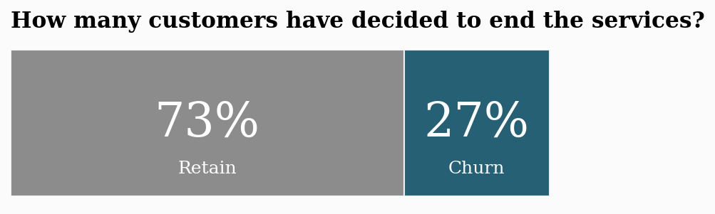

```python
x = df.groupby(['Churn'])['Churn'].count()
y = len(df)
r = ((x/y)).round(2)
ratio = pd.DataFrame(r).T

fig, ax = plt.subplots(1,1,figsize=(6.5, 2), dpi=150)
background_color = '#fbfbfb'
fig.patch.set_facecolor(background_color)
ax.set_facecolor(background_color)

ax.barh(ratio.index, ratio['No'], color='gray', alpha=0.9,
       ec=background_color, label='Retain')
ax.barh(ratio.index, ratio['Yes'], left=ratio['No'], color='#0e4f66',
       alpha=0.9, ec=background_color, label='Churn')

ax.set_xlim(0,1)
ax.set_xticks([])
ax.set_yticks([])
ax.legend().set_visible(False)
for s in ['top', 'left', 'right', 'bottom']:
    ax.spines[s].set_visible(False)

for i in ratio.index:
    ax.annotate(f"{int(ratio['No'][i]*100)}%", xy=(ratio['No'][i]/2, i),
               va = 'center', ha= 'center', fontsize=32, fontweight='light',
               fontfamily='serif', color='white')
    ax.annotate('Retain', xy=(ratio['No'][i]/2, -0.25), va='center', ha='center',
               fontsize=12, fontweight='light', fontfamily='serif', color='white')

for i in ratio.index:
    ax.annotate(f"{int(ratio['Yes'][i]*100)}%", xy=(ratio['No'][i]+ratio['Yes'][i]/2, i),
               va='center', ha='center', fontsize=32, fontweight='light', fontfamily='serif', color='white')
    ax.annotate('Churn', xy=(ratio['No'][i]+ratio['Yes'][i]/2, -0.25),
               va='center', ha='center', fontsize=12, fontweight='light', fontfamily='serif', color='white')

fig.text(0.125, 0.95, 'How many customers have decided to end the services?', fontfamily='serif',
        fontsize=15, fontweight='bold')


plt.show()
```

## Internet Service

We found that using different internet service made differences between retain and churn groups.

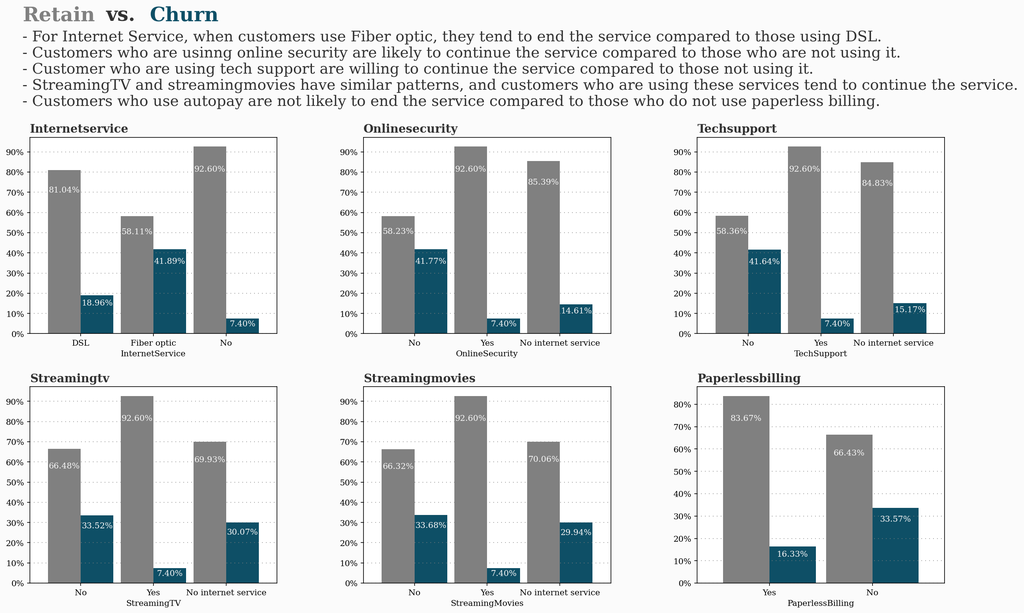

```python
background_color = '#fbfbfb'

fig = plt.figure(figsize=(20,10), dpi=150)
fig.patch.set_facecolor(background_color)
gs = fig.add_gridspec(2,3)
gs.update(wspace=0.35, hspace=0.27)

# axes as a list
axes = [fig.add_subplot(gs[0,0]),
        fig.add_subplot(gs[0,1]),
       fig.add_subplot(gs[0,2]),
       fig.add_subplot(gs[1,0]),
       fig.add_subplot(gs[1,1]),
       fig.add_subplot(gs[1,2])]

# categories as a list
cats = ['InternetService','OnlineSecurity','TechSupport','StreamingTV','StreamingMovies','PaperlessBilling']

# ticklabels as a list
tlabs = [['DSL', 'Fiber optic', 'No']] + [['No', 'Yes', 'No internet service']]*4 + [['Yes','No']]

axes[0].text(-0.80, 155, 'Retain', fontsize=24,
        fontweight='bold', fontfamily='serif', color='gray')
axes[0].text(0.35, 155, 'vs.', fontsize=24,
        fontweight='bold', fontfamily='serif', color='#323232')
axes[0].text(0.95, 155, 'Churn', fontsize=24,
        fontweight='bold', fontfamily='serif', color='#0e4f66')
axes[0].text(-0.80, 145, '- For Internet Service, when customers use Fiber optic, they tend to end the service compared to those using DSL.',
        fontsize=18, fontfamily='serif', color='#323232')
axes[0].text(-0.80, 137, '- Customers who are usinng online security are likely to continue the service compared to those who are not using it.',
        fontsize=18, fontfamily='serif', color='#323232')
axes[0].text(-0.80, 129, '- Customer who are using tech support are willing to continue the service compared to those not using it.',
        fontsize=18, fontfamily='serif', color='#323232')
axes[0].text(-0.80, 121, '- StreamingTV and streamingmovies have similar patterns, and customers who are using these services tend to continue the service.',
        fontsize=18, fontfamily='serif', color='#323232')
axes[0].text(-0.80, 113, '- Customers who use autopay are not likely to end the service compared to those who do not use paperless billing.',
        fontsize=18, fontfamily='serif', color='#323232')

for ax, xVar, ticklabels in zip(axes, cats, tlabs):
    GrpSubplots(df, xVar, ax, axis=1, ticklabels=ticklabels)
```

## Monthly Charge

We found monthly charge has a negative effect on churn customers. High payment made them decide to quit the service.

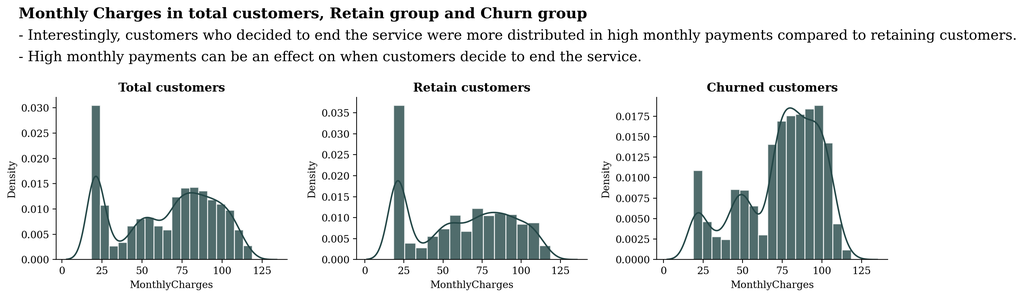

```python
import matplotlib.gridspec as gridspec

gs = gridspec.GridSpec(1,3)

fig = plt.figure(figsize=(15,3))

fig.text(0.09, 1.25, 'Monthly Charges in total customers, Retain group and Churn group',
        fontsize=15, fontweight='bold', fontfamily='serif')
fig.text(0.09, 1.15, '- Interestingly, customers who decided to end the service were more distributed in high monthly payments compared to retaining customers.',
        fontsize=14, fontfamily='serif')
fig.text(0.09, 1.05, '- High monthly payments can be an effect on when customers decide to end the service.',
        fontsize=14, fontfamily='serif')

ax1 = fig.add_subplot(gs[0, 0])
ax1 = sns.distplot(df['MonthlyCharges'], color='#244747', hist_kws=dict(edgecolor='white',
                                                                      linewidth=1, alpha=0.8))
ax1.set_title('Total customers', fontweight='bold')

ax2 = fig.add_subplot(gs[0, 1])
ax2 = sns.distplot(Retain['MonthlyCharges'], color='#244747', hist_kws=dict(edgecolor='white',
                                                                           linewidth=1, alpha=0.8))
ax2.set_title('Retain customers', fontweight='bold')
ax3 = fig.add_subplot(gs[0, 2])
ax3 = sns.distplot(Churn['MonthlyCharges'], color='#244747', hist_kws=dict(edgecolor='white',
                                                                          linewidth=1, alpha=0.8))
ax3.set_title('Churned customers', fontweight='bold')
sns.despine()

plt.subplots_adjust(left=None, bottom=None, right=None, top=None, wspace=0.3, hspace=None)
```

## Tenure

A large number of churn customers are relatively new to use the service.

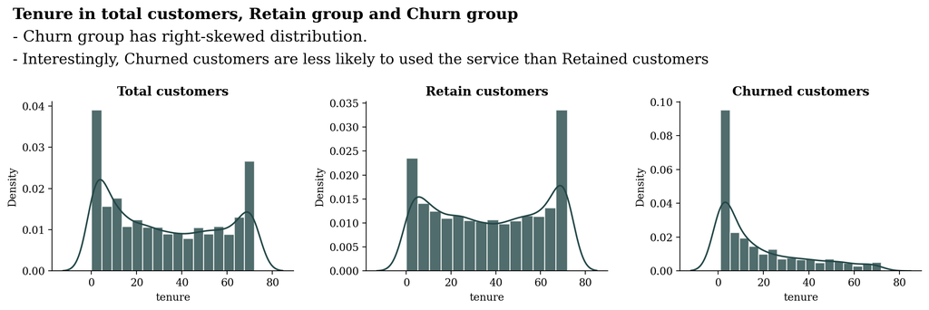

```python
Churn = df[df['Churn']=='Yes']
Retain = df[df['Churn']=='No']

gs = gridspec.GridSpec(1,3)

fig = plt.figure(figsize=(15,3))

fig.text(0.09, 1.25, 'Tenure in total customers, Retain group and Churn group',
        fontsize=15, fontweight='bold', fontfamily='serif')
fig.text(0.09, 1.15, "- Churn group has right-skewed distribution.",
        fontsize=15, fontfamily='serif')
fig.text(0.09, 1.05, "- Interestingly, Churned customers are less likely to used the service than Retained customers",
        fontsize=14, fontfamily='serif')

ax1 = fig.add_subplot(gs[0, 0])
ax1 = sns.distplot(df['tenure'], color='#244747', hist_kws=dict(edgecolor='white',
                                                                      linewidth=1, alpha=0.8))
ax1.set_title('Total customers', fontweight='bold')

ax2 = fig.add_subplot(gs[0, 1])
ax2 = sns.distplot(Retain['tenure'], color='#244747', hist_kws=dict(edgecolor='white',
                                                                           linewidth=1, alpha=0.8))
ax2.set_title('Retain customers', fontweight='bold')
ax3 = fig.add_subplot(gs[0, 2])
ax3 = sns.distplot(Churn['tenure'], color='#244747', hist_kws=dict(edgecolor='white',
                                                                          linewidth=1, alpha=0.8))
ax3.set_title('Churned customers', fontweight='bold')
sns.despine()

plt.subplots_adjust(left=None, bottom=None, right=None, top=None, wspace=0.3, hspace=None)
```

## Contract

Interestingly, customers who contracted on month-to-month are more likely to quit the service.

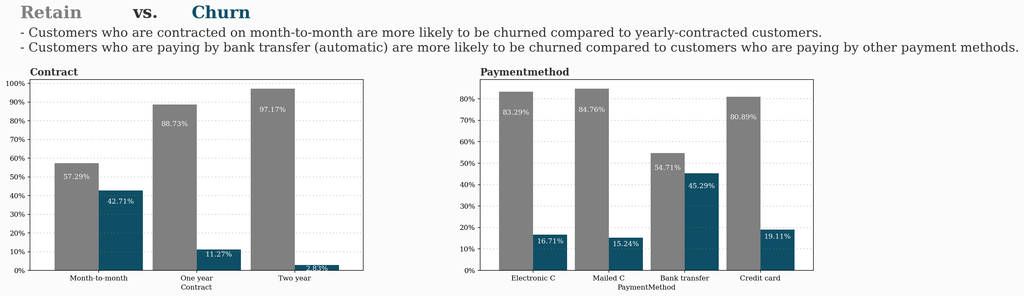

```python
Churn = df[df['Churn']=='Yes']
Retain = df[df['Churn']=='No']

background_color = '#fbfbfb'

fig = plt.figure(figsize=(20,5), dpi=150)
fig.patch.set_facecolor(background_color)
gs = fig.add_gridspec(1,2)
gs.update(wspace=0.35, hspace=0.27)

# axes as a list
axes = [fig.add_subplot(gs[0,0]),
        fig.add_subplot(gs[0,1])]

# categories as a list
cats = ['Contract', 'PaymentMethod']

# ticklabels as a list
tlabs = [['Month-to-month', 'One year', 'Two year']] + [['Electronic C', 'Mailed C', 'Bank transfer',
       'Credit card']]

axes[0].text(-0.80, 135, 'Retain', fontsize=24,
        fontweight='bold', fontfamily='serif', color='gray')
axes[0].text(0.35, 135, 'vs.', fontsize=24,
        fontweight='bold', fontfamily='serif', color='#323232')
axes[0].text(0.95, 135, 'Churn', fontsize=24,
        fontweight='bold', fontfamily='serif', color='#0e4f66')
axes[0].text(-0.80, 125, '- Customers who are contracted on month-to-month are more likely to be churned compared to yearly-contracted customers.',
        fontsize=18, fontfamily='serif', color='#323232')
axes[0].text(-0.80, 117, '- Customers who are paying by bank transfer (automatic) are more likely to be churned compared to customers who are paying by other payment methods.',
        fontsize=18, fontfamily='serif', color='#323232')


for ax, xVar, ticklabels in zip(axes, cats, tlabs):
    GrpSubplots(df, xVar, ax, axis=1, ticklabels=ticklabels)
```

## Relationship between features

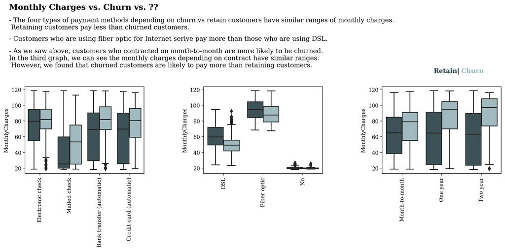

```python
import matplotlib.gridspec as gridspec

gs = gridspec.GridSpec(1,3)

fig = plt.figure(figsize=(16,3))


# Grid spec layout
ax1 = fig.add_subplot(gs[0,0])
sns.boxplot(x='PaymentMethod', y='MonthlyCharges', hue='Churn',
            data=df, palette=['#244247', '#91b7bd'], boxprops=dict(alpha=.9))
ax1.legend_.remove()
ax1.set_xlabel('')


ax2 = fig.add_subplot(gs[0,1])
sns.boxplot(x='InternetService', y='MonthlyCharges', hue='Churn',
            data=df, palette=['#244247', '#91b7bd'], boxprops=dict(alpha=.9))
ax2.legend_.remove()
ax2.set_xlabel('')

ax3 = fig.add_subplot(gs[0,2])
sns.boxplot(x='Contract', y='MonthlyCharges', hue='Churn',
            data=df, palette=['#244247', '#91b7bd'], boxprops=dict(alpha=.9))
ax3.legend_.remove()
ax3.set_xlabel('')

ax.legend().set_visible(False)
for tick in ax1.get_xticklabels():
    tick.set_rotation(90)
for tick in ax2.get_xticklabels():
    tick.set_rotation(90)
for tick in ax3.get_xticklabels():
    tick.set_rotation(90)

# adjust space between subplots
plt.subplots_adjust(left=None, bottom=None, right=None, top=None, wspace=0.5, hspace=None)

# Title and subtitles
fig.text(0.099, 1.55, 'Monthly Charges vs. Churn vs. ??', fontsize=15, fontweight='bold', fontfamily='serif')
fig.text(0.099, 1.38, '- The four types of payment methods depending on churn vs retain customers have similar ranges of monthly charges.\n Retaining customers pay less than churned customers.',
        fontsize=12, fontfamily='serif')
fig.text(0.099, 1.28, '- Customers who are using fiber optic for Internet serive pay more than those who are using DSL.',
        fontsize=12, fontfamily='serif')
fig.text(0.099, 1.05, '- As we saw above, customers who contracted on month-to-month are more likely to be churned. \nIn the third graph, we can see the monthly charges depending on contract have similar ranges.\n However, we found that churned customers are likely to pay more than retaining customers.',
        fontsize=12, fontfamily='serif')


# legend
fig.text(0.79, 1, 'Retain', fontweight='bold', fontfamily='serif', fontsize=12, color='#244247')
fig.text(0.828, 1, '|', fontweight='bold', fontfamily='serif', fontsize=12, color='black')
fig.text(0.835, 1, 'Churn', fontweight='bold', fontfamily='serif', fontsize=12, color='#91b9bd')
```

## Conclusion

In this project, we investigated what features have an effect on the customer retent.

We found that customers who were using fiber optic for Internet service tend to end the service compared to those using DSL. We cannot conclude that Fiber optic for Internet Service might have poor service compared to DSL from this dataset, but in the further research, if we can get more information on like service satisfaction, Internet service quality, the price of those services, then we can find more why customers churned.

We also found that churned customers tended to be charged monthly more compared to retaining customers, and high monthly payment can be an effect on customers’ decision on retaining or not.

Churned customers are distributed on relatively new contract on the service compared to retained customers. Since they have less loyalty to the service, they easily decided to quit the service.

Interestingly, when customers contract on month-to-month, they are more likely to churn compared to those contract on year-contract.

```python
!jupyter nbconvert Telco_presentation.ipynb --to slides --post serve --template output_toggle.tpl
```